# NLS Exploration of Lizard Weight to SVL

Margaret Hammond

2/7/2022

## 1. Overview

In this task, I will be using the Lightfoot (2020) data on lizards in the Jornada Basin LTER site, New Mexico, 1989-2006. I will be creating a non linear least squares model to estimate the parameters of a length to weight model for the lizard populations.

## 2. Explore the Data

### 2.1 Read in the data

```r
lizards <- read_csv(here("data", "lizard.csv")) %>%
  mutate(log_length = log(SV_length), # use log() to linearize the model
         log_weight = log(weight))
```

## 3. Set up the model

Must set up the NLS model of weight as a function of snout to vent length to be able to make guesses for coefficients a and b. Take the data and create a linear model in order for OLS regression to occur.

$$W = a(SVL)^b$$
In this model, W is weight, and SVL is snout to vent length.

```r
lizards_model <- function(a, SVL, b) {
  W = a*SVL^b
  return(W)
}
```

```r
parameter_guess <- lm(log_weight ~ log_length, data = lizards) # Created for OLS

lizards_coef <- coef(parameter_guess)

# lizards_coef checking the coefficients
```

## 4. Functions

Create the general lizards NLS model of weight as a function of snout to vent length.

```r
lizards_nls <- nls(weight ~ lizards_model(a, SV_length, b),
                   data = lizards,
                   start = list(
                     a = 2.718^(lizards_coef[1]/lizards_coef[2]),
                     b = lizards_coef[2]),
                   trace = TRUE)
```

### 4.1 Table of Model

This table shows the estimated parameters for the NLS model.

```r
tidy_nls <- tidy(lizards_nls)

tidy_nls$p.value <- ifelse(tidy_nls$p.value < .001, paste('< .001'))

tidy_nls %>%
  kable(col.names = c('Parameter',
                      'Estimated',
                      'Standard Error',
                      'Statistic',
                      'P Values'),
        caption = 'Table 1. Parameter estimates of coefficient a and b for the nls model of weight as a function of snout to vent length of lizards in Jornada Basin LTER, from 1989-2006 (Lightfoot 2020) .',
        digits = 4) %>%
  kable_classic(bootstrap_options = "striped", full_width = FALSE)
```

Table 1. Parameter estimates of coefficient a and b for the nls model of weight as a function of snout to vent length of lizards in Jornada Basin LTER, from 1989-2006 (Lightfoot 2020) .

| Parameter | Estimated | Standard Error | Statistic | P Values |
| --- | --- | --- | --- | --- |
| a | 0.0003 | 0.000 | 8.5384 | < .001 |
| b | 2.4532 | 0.027 | 90.9296 | < .001 |

### 4.2 NLS Predictions

I will use the NLS model to generate predictions of weight based on snout to vent length from the Lightfoot, 2020 data.

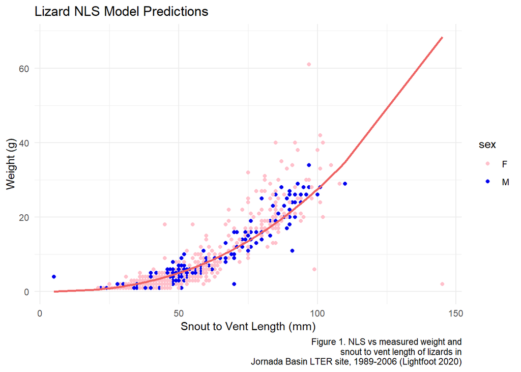

```r
general_mdl_pred <- predict(lizards_nls)


lizards_complete <- cbind(lizards, general_mdl_pred)

ggplot(data = lizards_complete,
       aes(x = SV_length,
           y = general_mdl_pred)) +
  geom_point(aes(x = SV_length, y = weight, color = sex)) +
  scale_color_manual(values = c('pink', 'blue2')) +
  geom_line(color = 'indianred2', size = 1) +
  labs(x = 'Snout to Vent Length (mm)',
       y = 'Weight (g)',
       title = "Lizard NLS Model Predictions",
       caption = 'Figure 1. NLS vs measured weight and
       snout to vent length of lizards in
       Jornada Basin LTER site, 1989-2006 (Lightfoot 2020)') +
  theme_minimal()
```